# Econ_123_DataReport

Kim Her

2022-11-17

## Data Sources

1. Data 2020: (race, homeownership, graduate status (high school and bachelor) of population 25 years and over, poverty rate) -adjust for state data https://www.census.gov/quickfacts/fact/table/US/EDU635220 2)Data (standardized test scores (math and reading)) adjust for math, reading, and time variables https://www.nationsreportcard.gov/profiles/stateprofile?chort=1&sub=MAT&sj=&sfj=NP&st=MN&year=2022R3 3)Data 2010: (graduate status (high school and bachelor) of population 25 years and over) -adjust for state data using Geos variable https://data.census.gov/table?tid=ACSDP5Y2020.DP02&g=0400000US06 4)Data (Real Median Household Income by State, Annual) -save individual state data and create a new data set with the fifty states https://fred.stlouisfed.org/release/tables?rid=249&eid=259515#snid=259517 5)Data 2010: (race) -adjust for state, race, and ethnicity variables, calculate percentage manually https://wonder.cdc.gov/single-race-single-year-v2016.html 6)Data 2010: (Home Ownership) https://www.infoplease.com/us/family-statistics/homeownership-state-2000-2007-and-2010 7)Data 2010:(poverty level) https://www2.census.gov/library/publications/2012/acs/acsbr11-01.pdf

## Data Set Description

The data set used is “Test_Score_vs_Income.csv”. The data set consist of 14 columns and 100 observation.This data set consist of the varables of state, test scores on NAEP, year, real median income, race, homeownership, graduate status, and poverty level. The data set covers two years worth of data for the year of 2009-10 and 2019-20 for all fifty states. There was inconsistency between US Census data and Testing Data, thus there is a gap between years. The dependent variable of the project is test score of students in the 8th grade. The independent variables are income, race, home stabaility, education of parents, and poverty of the students. The independent variables income and race are used to test social inequality effect of educational outcome. Meanwhile, the independent variables, home stability, education, and poverty is used to account for foundation for education; stability of home life and educational benefit from mentors and parents. ## CODEBOOK state: State in which the observation was taken math: Math score of 8th-grade students on the National Assessment of Educational Progress (NAEP) assessment reading: reading comprehensive score of 8th-grade students on the NAEP assessment comp: total score of reading and math NAEP for 8th graders year1: year data was taken for income and NAEP score income: real median household income of the state year2: year data was taken on racial demographic, homeownership, graduation status of the population, and poverty level white: percentage of the state population that classify as White, including those of Hispanic and Latino descent black: percentage of the state population that classify as Black latin: percentage of the state population that classify as Hispanic or Latino homeowner: percentage of the population that has ownership (full, partial, or mortgage) of their home highgrad: percentage of the population age 25 and over with a high school diploma and higher collegegrad: percentage of the population age 25 and over with a bachelor’s degree and higher poverty: percentage of people living in poverty in the state ## Summary Statistics of Relevent Variables set up workspace:

```r
library(readr)
test <- read_csv("C:/Users/yengl/OneDrive/Test_score_vs_Income.csv")
View(test)
```

## Summarize data:

```r
library(psych)
names(test)
```

```
##  [1] "state"       "math"        "reading"     "comp"        "year1"
##  [6] "income"      "year2"       "white"       "black"       "latin"
## [11] "homeowner"   "highgrad"    "collegegrad" "poverty"
```

```r
describe(test$comp)
```

|  | vars | n | mean | sd | median | trimmed | mad | min | max | range | skew | kurtosis | se |
| --- | --- | --- | --- | --- | --- | --- | --- | --- | --- | --- | --- | --- | --- |
| X1 | 1 | 100 | 545.22 | 11.86845 | 547 | 545.5375 | 11.8608 | 516 | 573 | 57 | -0.2567356 | -0.4940915 | 1.186845 |

```r
describe(test$income)
```

|  | vars | n | mean | sd | median | trimmed | mad | min | max | range | skew | kurtosis | se |
| --- | --- | --- | --- | --- | --- | --- | --- | --- | --- | --- | --- | --- | --- |
| X1 | 1 | 100 | 68210.08 | 11997.08 | 66323.5 | 67562.26 | 12602.84 | 44404 | 101283 | 56879 | 0.4289264 | -0.3678031 | 1199.708 |

```r
describe(test$homeowner)
```

|  | vars | n | mean | sd | median | trimmed | mad | min | max | range | skew | kurtosis | se |
| --- | --- | --- | --- | --- | --- | --- | --- | --- | --- | --- | --- | --- | --- |
| X1 | 1 | 100 | 67.809 | 4.723723 | 68.3 | 68.2075 | 3.92889 | 54.1 | 79 | 24.9 | -0.7970378 | 0.884922 | 0.4723723 |

```r
describe(test$highgrad)
```

|  | vars | n | mean | sd | median | trimmed | mad | min | max | range | skew | kurtosis | se |
| --- | --- | --- | --- | --- | --- | --- | --- | --- | --- | --- | --- | --- | --- |
| X1 | 1 | 100 | 88.508 | 3.647628 | 88.95 | 88.75625 | 3.33585 | 76.6 | 96.5 | 19.9 | -0.6384829 | 0.1392114 | 0.3647628 |

```r
describe(test$poverty)
```

|  | vars | n | mean | sd | median | trimmed | mad | min | max | range | skew | kurtosis | se |
| --- | --- | --- | --- | --- | --- | --- | --- | --- | --- | --- | --- | --- | --- |
| X1 | 1 | 100 | 13.611 | 3.071962 | 13.15 | 13.4275 | 3.18759 | 7.2 | 22.4 | 15.2 | 0.4966875 | -0.4122146 | 0.3071962 |

## Relevent Plots

Effect of Income on Test Score

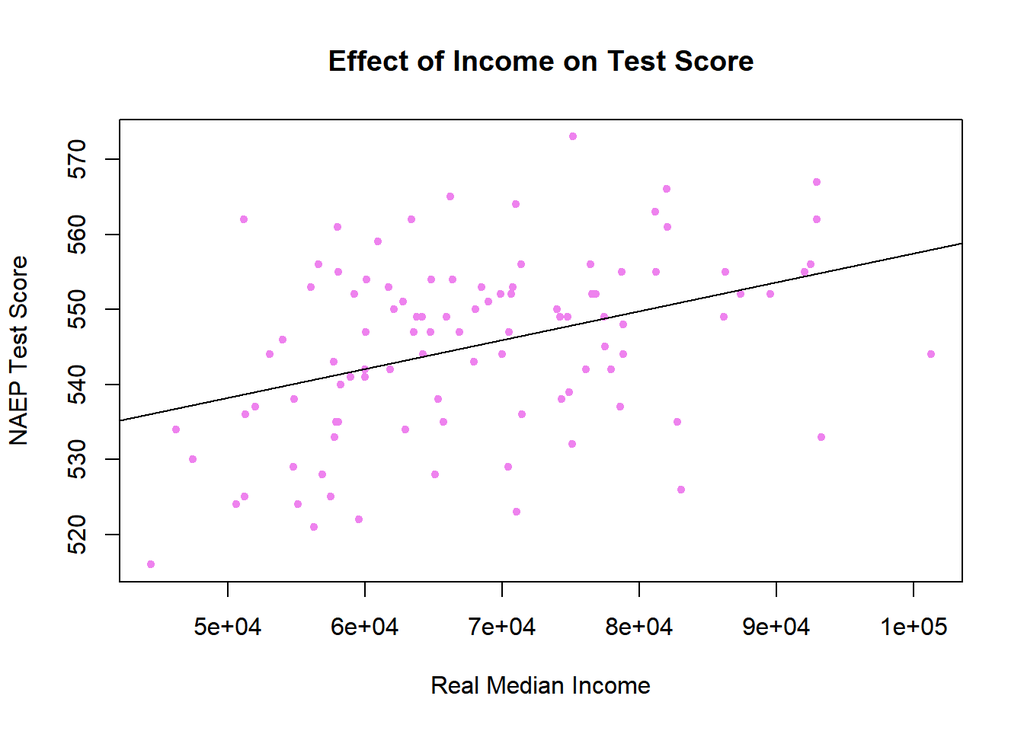

```r
plot(test$income,test$comp, xlab = "Real Median Income", ylab = "NAEP Test Score", main = "Effect of Income on Test Score", col="violet", pch=20)
ols1 <- lm(test$comp~test$income)
abline(ols1)
```

Effect of Race on Education

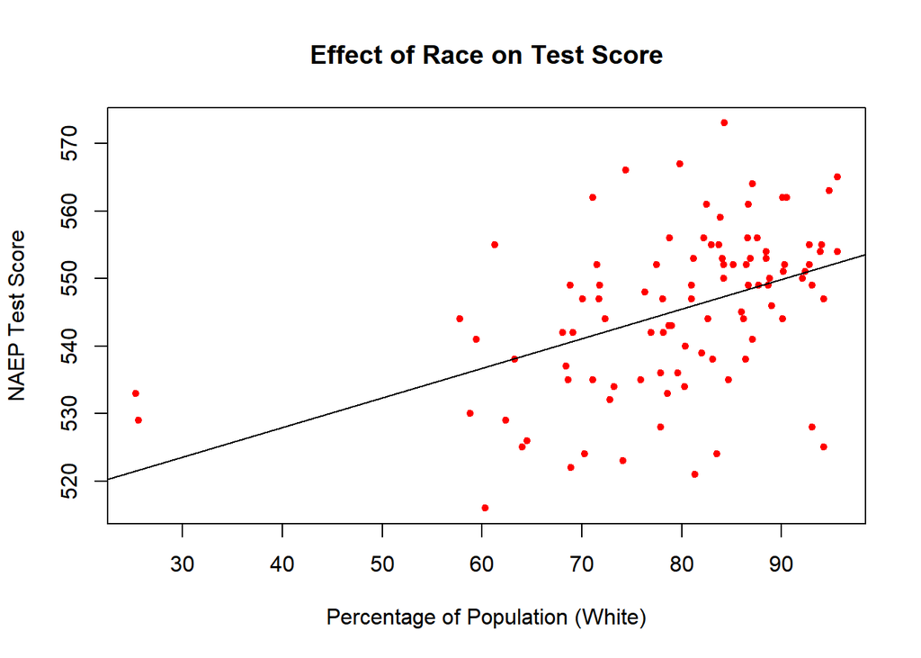

```r
plot(test$white,test$comp, xlab = "Percentage of Population (White)", ylab = "NAEP Test Score", main = "Effect of Race on Test Score", col="red", pch=20)
ols2 <- lm(test$comp~test$white)
abline(ols2)
```

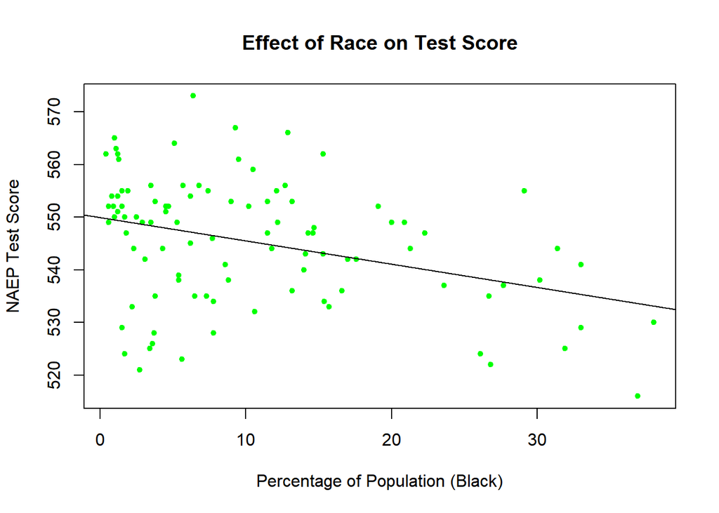

```r
plot(test$black,test$comp, xlab = "Percentage of Population (Black)", ylab = "NAEP Test Score", main = "Effect of Race on Test Score", col="green", pch=20)
ols3 <- lm(test$comp~test$black)
abline(ols3)
```

[figure not shown]

```r
plot(test$white,test$comp, xlab = "Percentage of Population (Latino/Hispanic)", ylab = "NAEP Test Score", main = "Effect of Race on Test Score", col="blue", pch=20)
ols4 <- lm(test$comp~test$latin)
abline(ols4)
```

Effect of Community Educational Achievement on Test Score

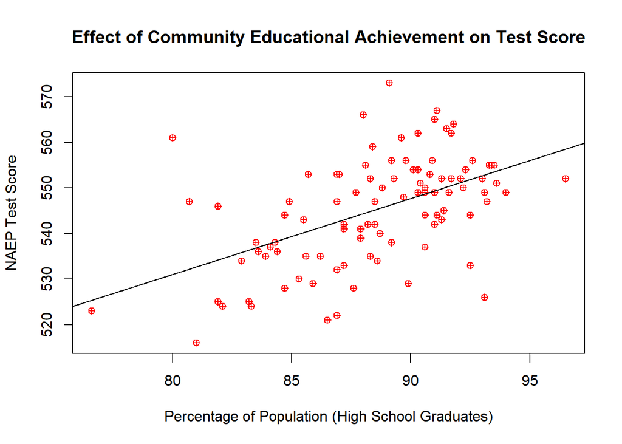

```r
plot(test$highgrad,test$comp, xlab = "Percentage of Population (High School Graduates)", ylab = "NAEP Test Score", main = "Effect of Community Educational Achievement on Test Score", col="red", pch=10)
ols5 <- lm(test$comp~test$highgrad)
abline(ols5)
```

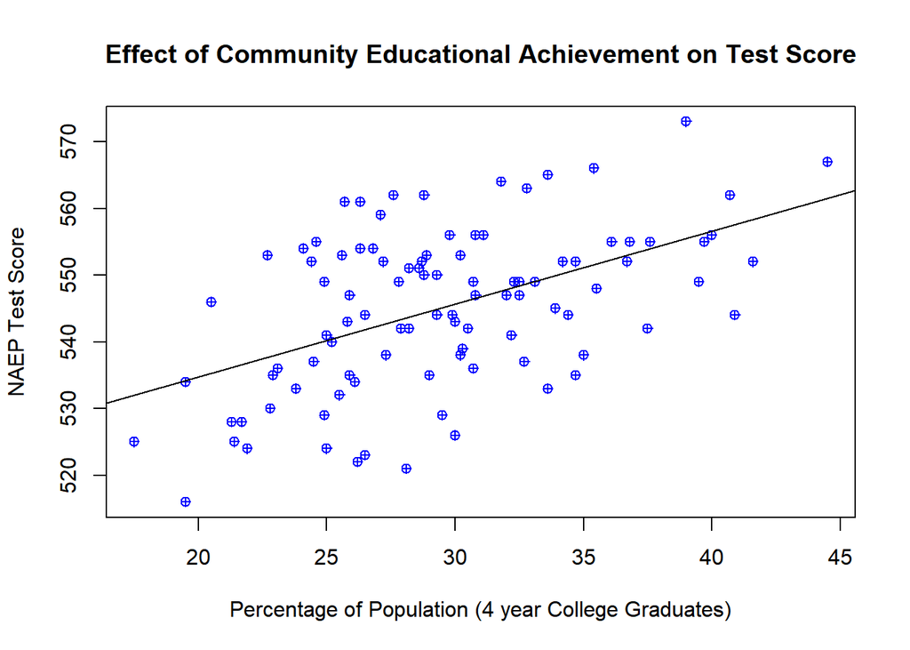

```r
plot(test$collegegrad,test$comp, xlab = "Percentage of Population (4 year College Graduates)", ylab = "NAEP Test Score", main = "Effect of Community Educational Achievement on Test Score", col="blue", pch=10)
ols6 <- lm(test$comp~test$collegegrad)
abline(ols6)
```

Effect of Housing Stability on Test Scores

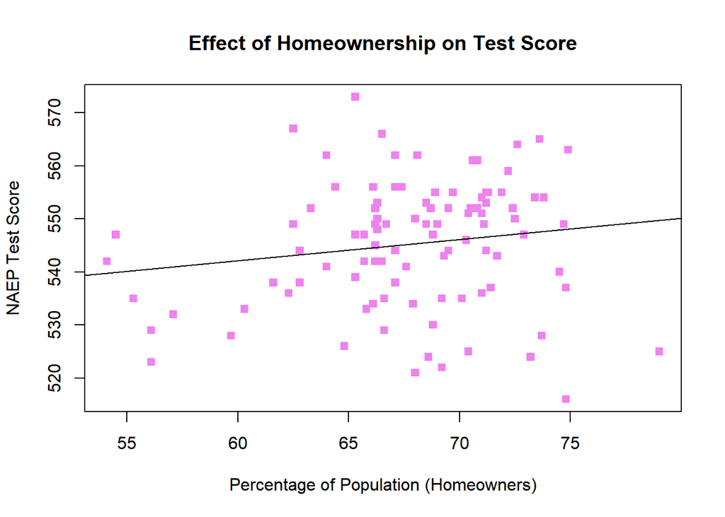

```r
plot(test$homeowner,test$comp, xlab = "Percentage of Population (Homeowners)", ylab = "NAEP Test Score", main = "Effect of Homeownership on Test Score", col="violet", pch=15)
ols7 <- lm(test$comp~test$homeowner)
abline(ols7)
```

[figure not shown]

```r
plot(test$homeowner,test$comp, xlab = "Percentage of Population in Poverty", ylab = "NAEP Test Score", main = "Effect of Poverty on Test Score", col="green", pch=15)
ols8 <- lm(test$comp~test$poverty)
abline(ols8)
```

## Transformation

The data is a mixture of pre-exisiting files and manuel inputed data. I started my file, “Test_Score_vs_Income.csv” by downloading for test score data sets for math and reading for the years of 2019 and 2009. I alphebehtized the downloaded data sets and copy the states and scores onto my excel sheet, and deleting the data for Washington DC and Purto Rico. Next I moved to the income variable and downloaded a custom file from FRED compiling real median income from the fifty states individually. I copy and pasted the income coluem from the FRED file to my file. The rest of the variables, exculding the 2010 data for poverty and home ownership, were manuelly inputed, by adjusting the states and the parameter, then inputing the data into my spreadsheet. For the 2010, data on race, I manually calculated the percentage using the data from the CDC site, then inputed the values into the spreadsheet. After compiling alll the data from the various sources, I added time stamps to easily identify the time period when the data set is created.

models Test Scorei = β0 + β1 Incomei + εi

```r
summary(ols1)
```

```
##
## Call:
## lm(formula = test$comp ~ test$income)
##
## Residuals:
##      Min       1Q   Median       3Q      Max
## -24.9439  -7.0446   0.7379   6.8654  25.1054
##
## Coefficients:
##              Estimate Std. Error t value Pr(>|t|)
## (Intercept) 5.190e+02  6.375e+00  81.411  < 2e-16 ***
## test$income 3.850e-04  9.206e-05   4.182  6.3e-05 ***
## ---
## Signif. codes:  0 '***' 0.001 '**' 0.01 '*' 0.05 '.' 0.1 ' ' 1
##
## Residual standard error: 10.99 on 98 degrees of freedom
## Multiple R-squared:  0.1514, Adjusted R-squared:  0.1428
## F-statistic: 17.49 on 1 and 98 DF,  p-value: 6.301e-05
```

Test Scorei = β0 + β1 Incomei + β2 Blacki + β3 Latini + εi

```r
describe(test$black)
```

|  | vars | n | mean | sd | median | trimmed | mad | min | max | range | skew | kurtosis | se |
| --- | --- | --- | --- | --- | --- | --- | --- | --- | --- | --- | --- | --- | --- |
| X1 | 1 | 100 | 10.717 | 9.545945 | 7.75 | 9.31125 | 8.45082 | 0.4 | 38 | 37.6 | 1.075954 | 0.2951188 | 0.9545945 |

```r
describe(test$latin)
```

|  | vars | n | mean | sd | median | trimmed | mad | min | max | range | skew | kurtosis | se |
| --- | --- | --- | --- | --- | --- | --- | --- | --- | --- | --- | --- | --- | --- |
| X1 | 1 | 100 | 15.468 | 17.53455 | 9.1 | 11.6075 | 6.96822 | 1.2 | 92.5 | 91.3 | 2.314043 | 5.450418 | 1.753455 |

```r
olsir <- lm(test$comp~test$income+test$black+test$latin)
summary(olsir)
```

```
##
## Call:
## lm(formula = test$comp ~ test$income + test$black + test$latin)
##
## Residuals:
##     Min      1Q  Median      3Q     Max
## -28.128  -6.585   1.204   6.848  23.013
##
## Coefficients:
##               Estimate Std. Error t value Pr(>|t|)
## (Intercept)  5.255e+02  6.562e+00  80.084  < 2e-16 ***
## test$income  3.702e-04  9.190e-05   4.028 0.000112 ***
## test$black  -3.368e-01  1.121e-01  -3.004 0.003400 **
## test$latin  -1.263e-01  6.134e-02  -2.059 0.042222 *
## ---
## Signif. codes:  0 '***' 0.001 '**' 0.01 '*' 0.05 '.' 0.1 ' ' 1
##
## Residual standard error: 10.36 on 96 degrees of freedom
## Multiple R-squared:  0.2606, Adjusted R-squared:  0.2375
## F-statistic: 11.28 on 3 and 96 DF,  p-value: 2.108e-06
```

Test Scorei = β0 + β1 Incomei + β2 Homei + β3 Povertyi + εi

```r
olsih <- lm(test$comp~test$income+test$homeowner+test$poverty)
summary(olsih)
```

```
##
## Call:
## lm(formula = test$comp ~ test$income + test$homeowner + test$poverty)
##
## Residuals:
##      Min       1Q   Median       3Q      Max
## -24.0615  -5.2028  -0.5198   6.4665  23.3990
##
## Coefficients:
##                  Estimate Std. Error t value Pr(>|t|)
## (Intercept)     5.824e+02  2.595e+01  22.438  < 2e-16 ***
## test$income    -3.063e-04  1.517e-04  -2.020   0.0462 *
## test$homeowner  4.549e-01  2.078e-01   2.189   0.0310 *
## test$poverty   -3.460e+00  5.661e-01  -6.113  2.1e-08 ***
## ---
## Signif. codes:  0 '***' 0.001 '**' 0.01 '*' 0.05 '.' 0.1 ' ' 1
##
## Residual standard error: 8.908 on 96 degrees of freedom
## Multiple R-squared:  0.4537, Adjusted R-squared:  0.4366
## F-statistic: 26.58 on 3 and 96 DF,  p-value: 1.338e-12
```

Test Scorei = β0 + β1 Incomei + β2 Highi + εi

```r
olsis <- lm(test$comp~test$income+test$highgrad)
summary(olsis)
```

```
##
## Call:
## lm(formula = test$comp ~ test$income + test$highgrad)
##
## Residuals:
##      Min       1Q   Median       3Q      Max
## -28.0727  -6.3655  -0.7184   6.7368  25.7888
##
## Coefficients:
##                Estimate Std. Error t value Pr(>|t|)
## (Intercept)   4.115e+02  2.605e+01  15.794  < 2e-16 ***
## test$income   1.689e-04  9.913e-05   1.704   0.0916 .
## test$highgrad 1.381e+00  3.261e-01   4.235  5.2e-05 ***
## ---
## Signif. codes:  0 '***' 0.001 '**' 0.01 '*' 0.05 '.' 0.1 ' ' 1
##
## Residual standard error: 10.15 on 97 degrees of freedom
## Multiple R-squared:  0.2838, Adjusted R-squared:  0.2691
## F-statistic: 19.22 on 2 and 97 DF,  p-value: 9.291e-08
```

Test Scorei = β0 + β1 Incomei + β2 Homei + β3 Povertyi + β4 Blacki + β5 Latini + β6 Highi + εi

```r
olsit <- lm(test$comp~test$income+test$homeowner+test$poverty+test$black+test$latin+test$highgrad)
summary(olsit)
```

```
##
## Call:
## lm(formula = test$comp ~ test$income + test$homeowner + test$poverty +
##     test$black + test$latin + test$highgrad)
##
## Residuals:
##      Min       1Q   Median       3Q      Max
## -24.7958  -4.8161  -0.5264   5.7221  22.9358
##
## Coefficients:
##                  Estimate Std. Error t value Pr(>|t|)
## (Intercept)     5.837e+02  4.751e+01  12.284  < 2e-16 ***
## test$income    -2.431e-04  1.679e-04  -1.448   0.1510
## test$homeowner  4.774e-01  2.161e-01   2.209   0.0296 *
## test$poverty   -3.194e+00  7.701e-01  -4.148 7.42e-05 ***
## test$black     -1.307e-01  1.063e-01  -1.230   0.2218
## test$latin     -2.807e-02  5.565e-02  -0.504   0.6152
## test$highgrad  -1.008e-01  3.931e-01  -0.256   0.7982
## ---
## Signif. codes:  0 '***' 0.001 '**' 0.01 '*' 0.05 '.' 0.1 ' ' 1
##
## Residual standard error: 8.968 on 93 degrees of freedom
## Multiple R-squared:  0.4637, Adjusted R-squared:  0.429
## F-statistic:  13.4 on 6 and 93 DF,  p-value: 6.827e-11
```